# Final Project Write Up

Kailash Baskar - W0790883

### *Project*

This project is about exploring the famous German credit risk data set and provide insights on whether a particular customer’s credit is a good one or bad.

#### *Introduction*

The German credit data is the information collected from random 1000 customers about various attributes such as Credit amount, amount which is currently in their savings and checking account, their reason to avail credit from bank, tenure period of the credit and some personal information including age, sex, their occupation and whether they have their own house or not.

With these available information the project is intended to predict and showcase the relationship between the available attributes in the data and to check which customer’s credit is at Risk or not.

Also as part of this project using various regression techniques a new model will be created which helps whether a customer with the existing attributes will be a good credit candidate i.e will be paying back the credit on time or is there any risk associated in approving the loan to him.

##### *Analysis:*

##### *Loading the data required libraries:*

Let’s load the data set and explore the variables in it.

```r
library(tidyverse)
library(Hmisc)
library(patchwork)
library(corrplot)
library(Amelia)
library(here)
library(readr)
gd <- read_csv("./data/german_credit_data.csv")
```

##### *Exploratory data analysis*

In Exploratory data analysis we shall explore how wide spread the data is and also do the required cleanup and transformation and perform the required analysis.

Dimension of the data set.

```r
dim(gd)
```

```
## [1] 1000   11
```

Let’s have a glimpse of data set to ensure if all the variables are needed for our analysis.

```r
glimpse(gd)
```

```
## Rows: 1,000
## Columns: 11
## $ ...1               <dbl> 0, 1, 2, 3, 4, 5, 6, 7, 8, 9, 10, 11, 12, 13, 14, 1~
## $ Age                <dbl> 67, 22, 49, 45, 53, 35, 53, 35, 61, 28, 25, 24, 22,~
## $ Sex                <chr> "male", "female", "male", "male", "male", "male", "~
## $ Job                <dbl> 2, 2, 1, 2, 2, 1, 2, 3, 1, 3, 2, 2, 2, 1, 2, 1, 2, ~
## $ Housing            <chr> "own", "own", "own", "free", "free", "free", "own",~
## $ `Saving accounts`  <chr> NA, "little", "little", "little", "little", NA, "qu~
## $ `Checking account` <chr> "little", "moderate", NA, "little", "little", NA, N~
## $ `Credit amount`    <dbl> 1169, 5951, 2096, 7882, 4870, 9055, 2835, 6948, 305~
## $ Duration           <dbl> 6, 48, 12, 42, 24, 36, 24, 36, 12, 30, 12, 48, 12, ~
## $ Purpose            <chr> "radio/TV", "radio/TV", "education", "furniture/equ~
## $ Risk               <chr> "good", "bad", "good", "good", "bad", "good", "good~
```

##### *Data cleaning and transformation*

From the data looks like the first column is just Serial numbers and it would not be useful for our analysis, hence removing the first column in the data set.

```r
gd <- gd %>% select(!...1)
head(gd, n=2)
```

| Age | Sex | Job | Housing | Saving accounts | Checking account | Credit amount | Duration | Purpose | Risk |
| --- | --- | --- | --- | --- | --- | --- | --- | --- | --- |
| 67 | male | 2 | own | NA | little | 1169 | 6 | radio/TV | good |
| 22 | female | 2 | own | little | moderate | 5951 | 48 | radio/TV | bad |

Let’s check if there are any missing values in any variables in it.

```r
apply(is.na(gd),2,sum)
```

```
##              Age              Sex              Job          Housing
##                0                0                0                0
##  Saving accounts Checking account    Credit amount         Duration
##              183              394                0                0
##          Purpose             Risk
##                0                0
```

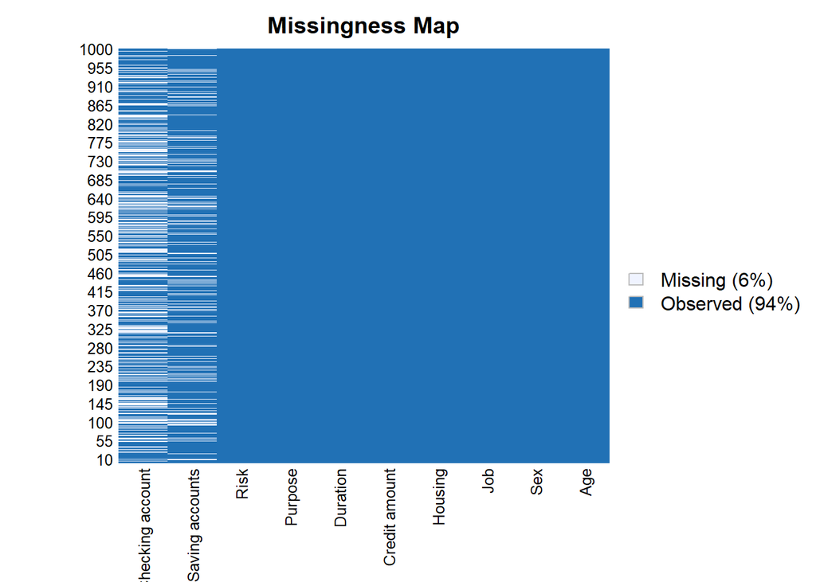

```r
missmap(gd)
```

From the above graph we could see the variables `Checking account` and `Savings account` has multiple `NA` values in it.

Calculating the percentage of NA values to see if it is less than 5% then we can remove those observations.

```r
print("NA count for Saving accounts")
```

```
## [1] "NA count for Saving accounts"
```

```r
apply(is.na(gd['Saving accounts']), 2, sum)/count(gd[1])*100
```

| n |
| --- |
| 18.3 |

```r
print("NA count for Saving accounts")
```

```
## [1] "NA count for Saving accounts"
```

```r
apply(is.na(gd['Checking account']), 2, sum)/count(gd[1])*100
```

| n |
| --- |
| 39.4 |

Looks like the NA values contribute to a higher percentage of data. So replacing the `NA` observations to some value to make the data useful for our analysis.

Replacing the value “NO” for the observations which has “NA” in Savings and Checking account variables.

```r
gd['Saving accounts'][is.na(gd['Saving accounts'])] <- "NO"
gd['Checking account'][is.na(gd['Checking account'])] <- "NO"
```

```r
count(gd, gd$`Saving accounts`)
```

| gd$`Saving accounts` | n |
| --- | --- |
| little | 603 |
| moderate | 103 |
| NO | 183 |
| quite rich | 63 |
| rich | 48 |

```r
count(gd, gd$`Checking account`)
```

| gd$`Checking account` | n |
| --- | --- |
| little | 274 |
| moderate | 269 |
| NO | 394 |
| rich | 63 |

Replaced the “NA” values to “NO” to indicate there is no savings or checking account for that customer.

To check the correlation of these account types lets map them to a numerical value to find correlation with other variables.

```r
gd <- gd %>% mutate(savings_numeric=as.numeric(factor(gd$`Saving accounts`)))
gd <- gd %>% mutate(credit_numeric=as.numeric(factor(gd$`Credit amount`)))
```

Also mutating other relavent information into numeric values to calculate correlation.

```r
gd <- gd %>% mutate(Sex_num = as.numeric(factor(gd$Sex))) %>% mutate(Risk_num = as.numeric(factor(gd$Risk))) %>%  mutate(Housing_num = as.numeric(factor(gd$Housing))) %>% mutate(Purpose_num = as.numeric(factor(gd$Purpose)))
```

The current data set which we have after cleaning and transforming some of the variables.

```r
head(gd,2)
```

| Age | Sex | Job | Housing | Saving accounts | Checking account | Credit amount | Duration | Purpose | Risk | savings_numeric | credit_numeric | Sex_num | Risk_num | Housing_num | Purpose_num |
| --- | --- | --- | --- | --- | --- | --- | --- | --- | --- | --- | --- | --- | --- | --- | --- |
| 67 | male | 2 | own | NO | little | 1169 | 6 | radio/TV | good | 3 | 143 | 2 | 2 | 2 | 6 |
| 22 | female | 2 | own | little | moderate | 5951 | 48 | radio/TV | bad | 1 | 771 | 1 | 1 | 2 | 6 |

##### *Analysis:*

Plotting the variable helps in identification of their measure of spread, central tendency and other important features.

##### *Univariant Analysis:*

First let’s explore the numerical variables Age and Credit Amount.

```r
p1 <- ggplot(gd, aes(gd$Age)) + geom_histogram(binwidth = (max(gd$Age) - min(gd$Age))/30, color="white", fill="skyblue" ) + geom_vline(xintercept = mean(gd$Age), color="red", size=2) + geom_vline(xintercept = median(gd$Age), color="green", size=2) + labs(x="Age", y="Count of age", title="Age distribution among customers")

p2 <- ggplot(gd, aes(gd$`Credit amount`)) + geom_histogram(binwidth = (max(gd$`Credit amount`) - min(gd$`Credit amount`))/30, color="white", fill="skyblue" ) + geom_vline(xintercept = mean(gd$`Credit amount`), color="red", size=2) + geom_vline(xintercept = median(gd$`Credit amount`), color="green", size=2) + labs(x="Credit amount", y="Count of Credit amount", title="Credit amount distribution")
```

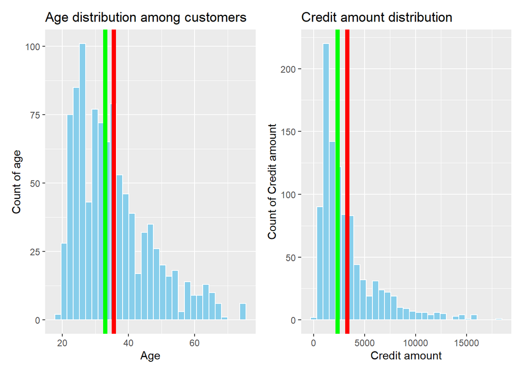

```r
p1 + p2
```

The red line indicates the mean and green line indicates the median.

Both the graphs indicate the variables are right skewed and unimodel.

The measure of spread of these variables are displayed below.

```r
print("IQR for Age")
```

```
## [1] "IQR for Age"
```

```r
IQR(gd$Age)
```

```
## [1] 15
```

```r
print("IQR for credit amount")
```

```
## [1] "IQR for credit amount"
```

```r
IQR(gd$`Credit amount`)
```

```
## [1] 2606.75
```

##### *Bivariant Analysis:*

Exploring other variables to check their distribution. The variable Job indicates the job category, using visualization plotting the bar graph along with Sex as distribution.

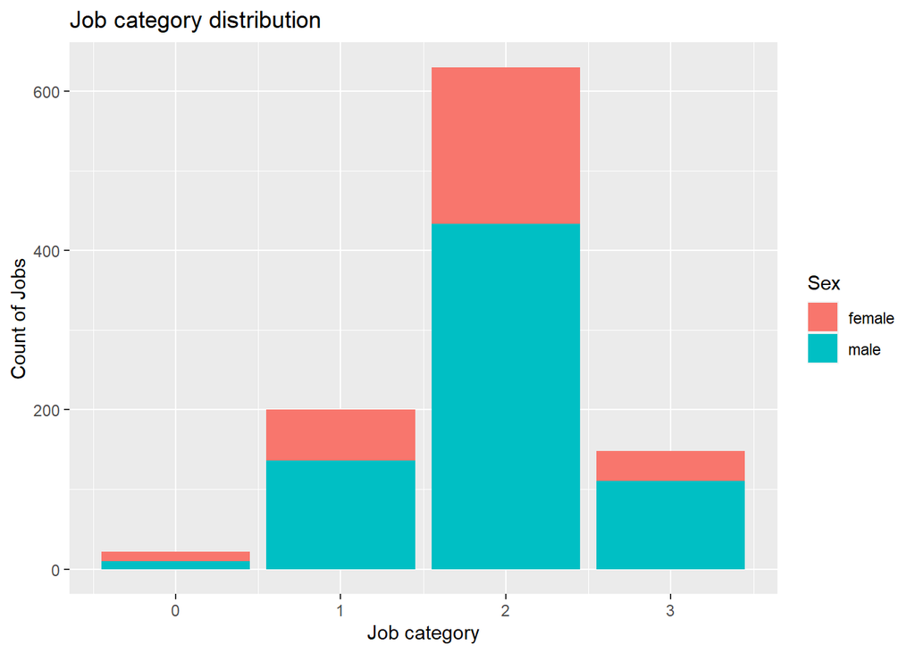

```r
ggplot(gd, aes(Job)) + geom_bar(aes(fill=Sex)) + labs(x="Job category", y="Count of Jobs", title="Job category distribution")
```

Finding out which gender has the most credit amount.

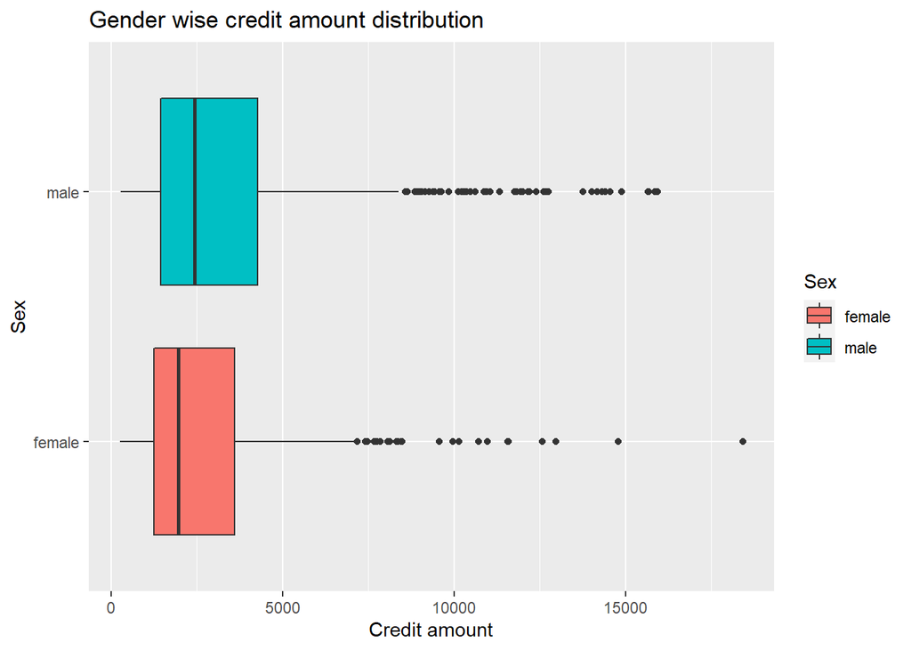

```r
ggplot(gd, aes(`Credit amount`, Sex)) + geom_boxplot(aes(fill=Sex)) + labs(x="Credit amount", y="Sex", title="Gender wise credit amount distribution")
```

From the graph it looks like though credit amount for females is less than males there are few female customers with high credit amount.

Let’s check the distribution of good and bad loans by sex.

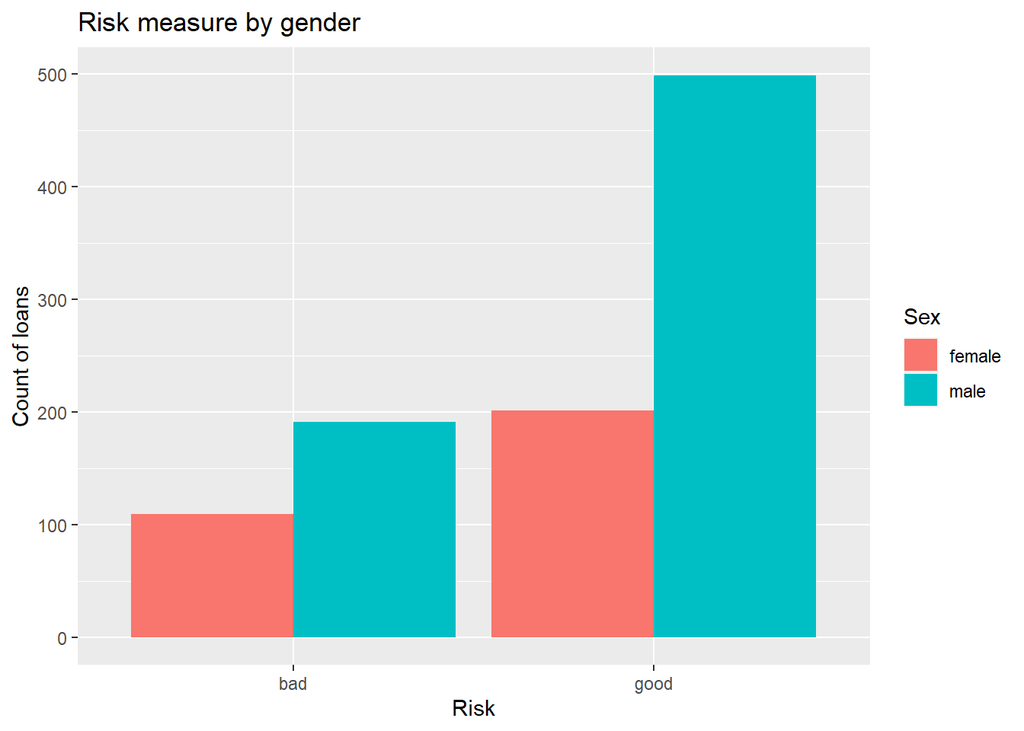

```r
ggplot(gd,aes(x=Risk, fill=Sex)) + geom_bar(position='dodge') + labs(x="Risk", y="Count of loans", title="Risk measure by gender")
```

From the graph it looks like more male customers are having a positive good risk score when compared to the females and looks like there are more risk associated with female customers.

A plot to compare credit amount with the purpose of credit.

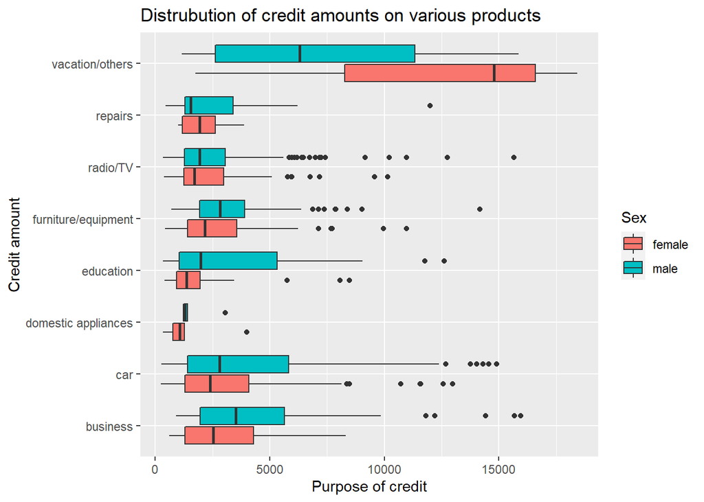

```r
ggplot(gd, aes(x=Purpose, y=gd$`Credit amount`, fill=Sex)) + geom_boxplot() + coord_flip() + labs(x="Credit amount", y="Purpose of credit", title="Distrubution of credit amounts on various products")
```

Let’s find the distribution of customers Age with their credit amount received from bank.

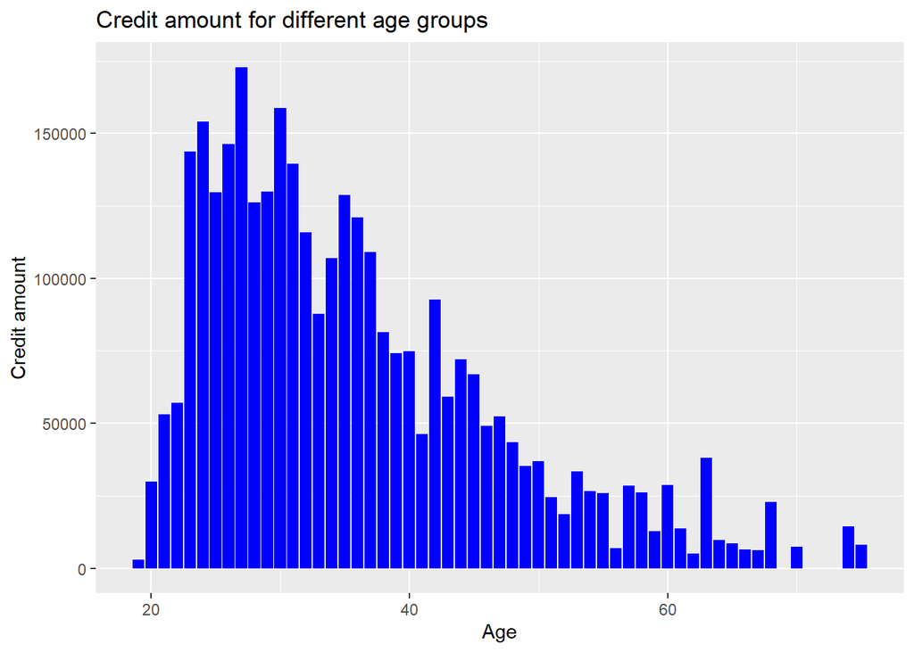

```r
ggplot(gd, aes(gd$Age, gd$`Credit amount`)) + geom_col(fill="blue") + labs(x="Age", y="Credit amount", title="Credit amount for different age groups")
```

From the graph it looks like customers in the age range of 23-40 has received the most credit amount when compared to the other age people.

Comparing credit amount with the customer’s house variable, to ensure if there are more loans given for customers with house or not.

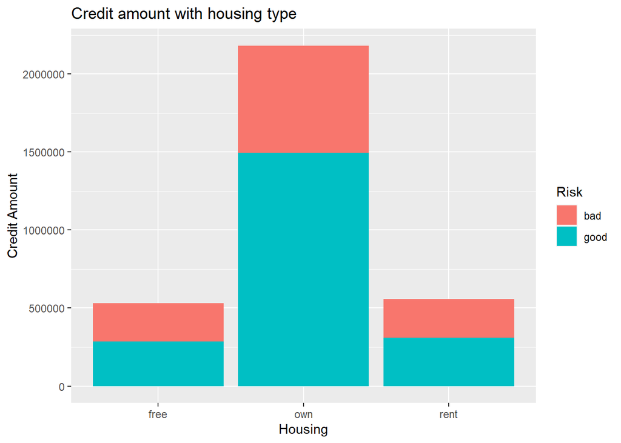

```r
ggplot(gd, aes(gd$Housing, gd$`Credit amount`)) + geom_col(aes(fill=Risk), show.legend = TRUE) + labs(x="Housing", y="Credit Amount", title="Credit amount with housing type")
```

Looks like customers with own house has received the most credit when compared to the other customers and also the risk factor is considerably low for the customer who owns a house.

Lets find the distrubution about how much duration varies with various credit amounts received by the customers.

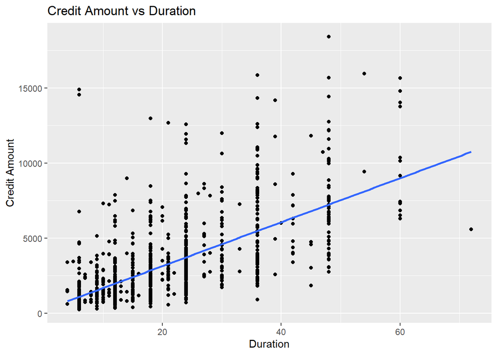

```r
ggplot(gd, aes(gd$Duration, gd$`Credit amount`)) + geom_point() + geom_smooth(method=lm, se=FALSE) + labs(x="Duration", y="Credit Amount", title="Credit Amount vs Duration")
```

From the above graph it is clear that as the duration increases the credit amount also increases i.e in other words the larger the credir amount the longer the credit duration.

Let’s find the correlation between the different variables with Risk to identify which variable correlates to the most risk value.

```r
print("Correlation of Age and Risk")
```

```
## [1] "Correlation of Age and Risk"
```

```r
cor(gd$Age, gd$Risk_num)
```

```
## [1] 0.09112741
```

```r
print("Correlation of Credit Amount and Risk")
```

```
## [1] "Correlation of Credit Amount and Risk"
```

```r
cor(gd$`Credit amount`, gd$Risk_num)
```

```
## [1] -0.1547386
```

```r
print("Correlation of Duration and Risk")
```

```
## [1] "Correlation of Duration and Risk"
```

```r
cor(gd$Duration, gd$Risk_num)
```

```
## [1] -0.2149267
```

Some statistical calculation to find out which category of customers with various housing and Job type has got the most credit amount from the bank and their average age and duration of the loan.

```r
print("Summary of mean grouped by House category")
```

```
## [1] "Summary of mean grouped by House category"
```

```r
gd %>% group_by(Housing) %>% summarise(mean(`Credit amount`), mean(Age), mean(Duration))
```

| Housing | mean(`Credit amount`) | mean(Age) | mean(Duration) |
| --- | --- | --- | --- |
| free | 4906.213 | 43.81481 | 27.45370 |
| own | 3060.940 | 35.59327 | 20.32819 |
| rent | 3122.553 | 30.36872 | 19.24022 |

```r
print("Summary of mean grouped by Job category")
```

```
## [1] "Summary of mean grouped by Job category"
```

```r
gd %>% group_by(Job) %>% summarise(mean(`Credit amount`), mean(Age), mean(Duration))
```

| Job | mean(`Credit amount`) | mean(Age) | mean(Duration) |
| --- | --- | --- | --- |
| 0 | 2745.136 | 40.09091 | 17.36364 |
| 1 | 2358.520 | 36.54000 | 16.53500 |
| 2 | 3070.965 | 34.25397 | 21.41111 |
| 3 | 5435.493 | 39.02703 | 25.16892 |

From the obtained information it looks like the people who are in free houses has got the most credit from the bank when compared to the Own house owners or rental people. The People in the free house category are also little old when compared to the other category people and they got a larger loan duration as well.

Similarly people who are belong and are working in job category 3 has got the maximul credit amount from the bank and also has the second highest age when compared with others and with the highest loan duration.

##### *Linear model:*

```r
summary(lm(gd$Risk_num~gd$`Credit amount`, data=gd))
```

```
##
## Call:
## lm(formula = gd$Risk_num ~ gd$`Credit amount`, data = gd)
##
## Residuals:
##     Min      1Q  Median      3Q     Max
## -0.7713 -0.6040  0.2541  0.2924  0.6163
##
## Coefficients:
##                      Estimate Std. Error t value Pr(>|t|)
## (Intercept)         1.782e+00  2.194e-02  81.220  < 2e-16 ***
## gd$`Credit amount` -2.513e-05  5.080e-06  -4.948  8.8e-07 ***
## ---
## Signif. codes:  0 '***' 0.001 '**' 0.01 '*' 0.05 '.' 0.1 ' ' 1
##
## Residual standard error: 0.4532 on 998 degrees of freedom
## Multiple R-squared:  0.02394,    Adjusted R-squared:  0.02297
## F-statistic: 24.48 on 1 and 998 DF,  p-value: 8.798e-07
```

So the least square for this regression model can be written as “r = 1.782 + (-2.513e-05) * Credit Amount” So 2.3% of the Risk variability is being explained by Credit Amount

Let’s extend this model for multiple variables to predict the risk.

Creating a model with all the variables to check if they correlate to the Risk factor.

```r
summary(lm( gd$Risk_num ~ as.numeric(gd$Job) + gd$Age + gd$Duration + gd$Purpose_num + gd$Sex_num + gd$savings_numeric + gd$credit_numeric + gd$Housing_num + gd$`Credit amount`, data=gd))
```

```
##
## Call:
## lm(formula = gd$Risk_num ~ as.numeric(gd$Job) + gd$Age + gd$Duration +
##     gd$Purpose_num + gd$Sex_num + gd$savings_numeric + gd$credit_numeric +
##     gd$Housing_num + gd$`Credit amount`, data = gd)
##
## Residuals:
##     Min      1Q  Median      3Q     Max
## -1.1323 -0.4842  0.1915  0.3154  0.9444
##
## Coefficients:
##                      Estimate Std. Error t value Pr(>|t|)
## (Intercept)         1.480e+00  1.206e-01  12.268  < 2e-16 ***
## as.numeric(gd$Job)  2.041e-03  2.211e-02   0.092 0.926493
## gd$Age              2.377e-03  1.288e-03   1.845 0.065367 .
## gd$Duration        -9.028e-03  1.519e-03  -5.942 3.90e-09 ***
## gd$Purpose_num      1.469e-02  7.070e-03   2.078 0.037935 *
## gd$Sex_num          7.022e-02  3.080e-02   2.280 0.022848 *
## gd$savings_numeric  6.846e-02  1.147e-02   5.971 3.28e-09 ***
## gd$credit_numeric   4.426e-04  1.061e-04   4.172 3.28e-05 ***
## gd$Housing_num     -2.843e-02  2.812e-02  -1.011 0.312160
## gd$`Credit amount` -3.723e-05  9.831e-06  -3.787 0.000161 ***
## ---
## Signif. codes:  0 '***' 0.001 '**' 0.01 '*' 0.05 '.' 0.1 ' ' 1
##
## Residual standard error: 0.4342 on 990 degrees of freedom
## Multiple R-squared:  0.111,  Adjusted R-squared:  0.103
## F-statistic: 13.74 on 9 and 990 DF,  p-value: < 2.2e-16
```

Let’s create a new model with a product of all these variables.

“summary(lm( gd$Risk_num ~ as.numeric(gd$Job) * gd$Age * gd$Duration * gd$Purpose_num * gd$Sex_num * gd$savings_numeric * gd$credit_numeric * gd$Housing_num + gd$`Credit amount`, data=gd))”

#Turned off the message output for second model as the output is lengthy and takes up more page space.

#### *Conclusion*

Overall there were multiple parameters in the data set about the customer which indicated some of the customer’s personal information as well as banking related information. We have performed extensive exploratory data analysis on continuous and categorical variable both univarent and bivarent analysis and identified some interesting aspects from the data.

To conclude, by extensive exploratory data analysis and linear model outputs we were able to find some interesting variables about the bank credits and also created a model to predict the risk factor of the future customers.

#### *References*

https://www.rdocumentation.org/packages/Amelia/versions/1.8.0/topics/missmap https://njtierney.github.io/r/missing%20data/rbloggers/2015/12/01/ggplot-missing-data/ [https://www.geeksforgeeks.org/convert-factor-to-numeric-and-numeric-to-factor-in-r-programming/](https://www.geeksforgeeks.org/convert-factor-to-numeric-and-numeric-to-factor-in-r-programming/￼DAB501)  
DAB501 study materials and LAB contents